# Geographic projections and transformations

# EPSG codes

EPSG codes are standard codes for projections. See them in R with:

```r
epsg_codes = rgdal::make_EPSG()
# View(epsg_codes) # open in interactive spreadsheet
```

In the UK, the EPSG code of official data is 27700

# Geographic data in R

```r
london_df = data.frame(name = "london", population = 1e7, lon = -0.1, lat = 51.5)
class(london_df)
```

```
#> [1] "data.frame"
```

```r
london = st_as_sf(london_df, coords = c("lon", "lat"))
class(london)
```

```
#> [1] "sf"         "data.frame"
```

```r
st_is_longlat(london)
```

```
#> [1] NA
```

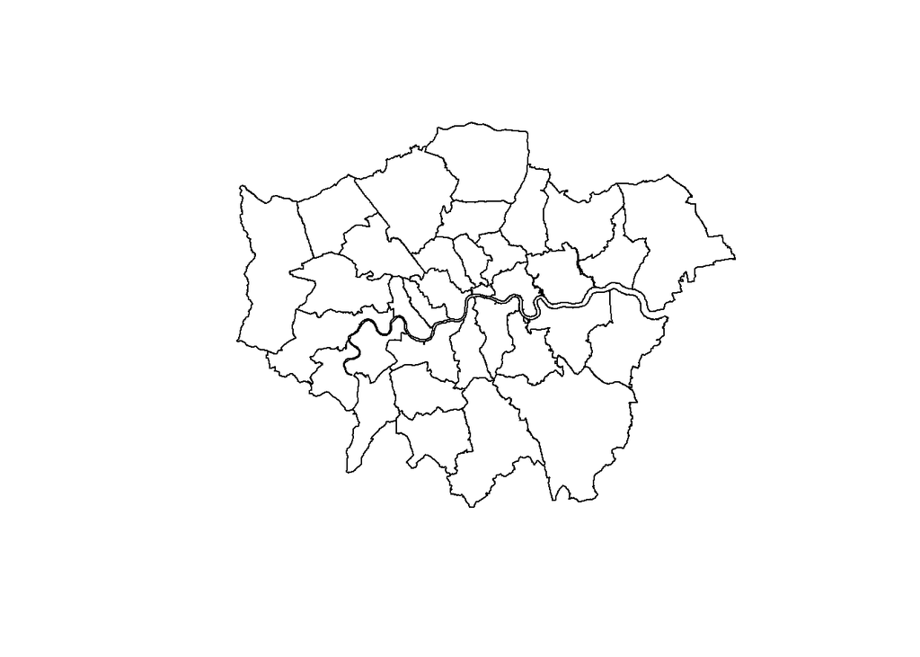

```r
plot(zones_london_projected$geometry)
plot(london$geometry, add = TRUE, pch = 9)
```

```r
st_crs(london) = 4326
london_projected = st_transform(london, 27700)
st_is_longlat(london_projected)
```

```
#> [1] FALSE
```

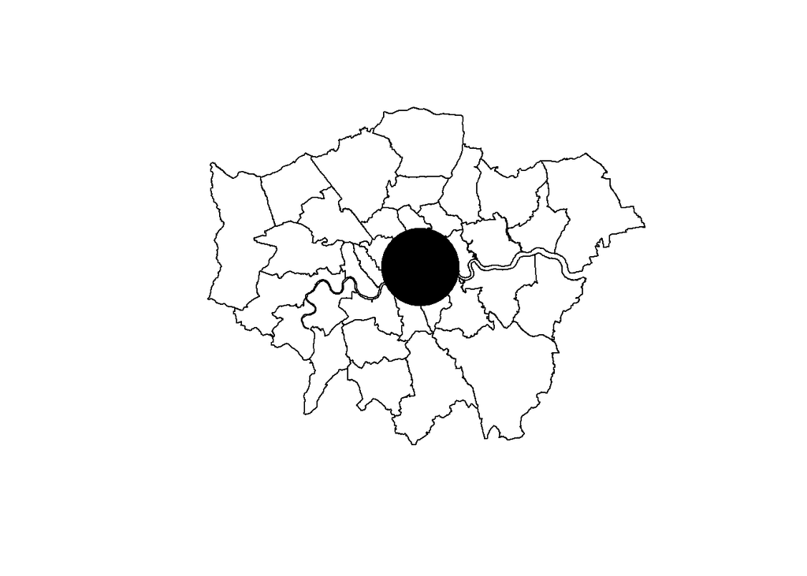

```r
plot(zones_london_projected$geometry)
plot(london_projected$geometry, add = TRUE, pch = 19, cex = 9)
```

# Further reading

If you’re interested in learning more on this, check out *Geocomputations with R*.

[figure not shown]

More specific resources on projections include:

- Excellent tutorial on coordinate systems on the Manifold website: http://www.manifold.net/doc/mfd9/projections_tutorial.htm
- An introduction to vector geographic data in *Geocomputation with R* (Section [2.2](https://geocompr.robinlovelace.net/spatial-class.html#vector-data))
- An introduction to CRSs in R (Section [2.4](https://geocompr.robinlovelace.net/spatial-class.html#crs-intro))
- The contents and exercises of Chapter [6](https://geocompr.robinlovelace.net/reproj-geo-data.html), solutions to which you can find at https://geocompr.github.io/geocompkg/articles/index.html
- For a fun take on projections, see https://xkcd.com/977/

Check out the questions in the exercises section of Chapter 6 of Geocomputation with R.